# `sf`パッケージと地理空間データの可視化

[岩田真一郎](https://shinichiro-iwata.github.io/)（ [神奈川大学経済学部](https://www.econ.kanagawa-u.ac.jp/)）

2025-02-27作成，2025-02-27改訂

# 1 目的

- [`sf`パッケージ](https://cran.r-project.org/web/packages/sf/index.html) を用いることで，[国土数値情報](https://nlftp.mlit.go.jp/ksj/)などで用意されている**シェープファイル**を可視できる．
  - ここでは，`sf`パッケージの仕組みと地理空間データの可視化を要約．

# 2 シェープファイル

- シェープファイルは**ベクターデータ**．ポイント（点），ライン（線），ポリゴン（面）で地理空間情報を表現．
  - ベクターデータの他，**ラスターデータ**がある．これは，セル（格子状の区画）で地理空間情報を表現．`terra`パッケージを利用．
- シェープファイルを`sf`パッケージで読み込むと`sf`**オブジェクト**．
  - オブジェクト：データを表現するための基本構造．ベクトル，行列，データフレーム，リスト，ファクターなどの種類がある．`R`ではデータはすべてオブジェクトとして格納．
  - `sf`オブジェクトは「`sf`クラス（クラスとはデータの種類，型のこと）のオブジェクト」のこと（湯谷，2018）．
  - `sf`オブジェクトは**データフレーム**．各行が1つの地物（点，線，面）を表し，列には属性情報が格納されている．最大の特徴が属性情報に**地理空間情報（geometry：ジオメトリ）**が格納されていること．地理空間情報は，他の属性情報の列と異なり`sfc`クラス．
    - データフレーム：異なる型のデータを列ごとに持つことができるオブジェクト．
    - ラスターデータのファイルを `terra` パッケージで読み込むと `SpatRaster`オブジェクト．

# 3 `sfg`，`sfc`，`sf`の関係

## 3.1 `sfg`オブジェクト

- `sfg`オブジェクト：点，線，面のいずれかを表す単一の地理空間情報．座標を持つが，座標参照系（`CRS`）は含まれない．
  - 神奈川大学（横浜キャンパス）の緯度経度を[MapFun](https://mapfan.com/)から取得し，`sfg`オブジェクトを作成．
    - 世界測地系：`WGS84`または`EPSG:4326`．

```r
library(sf)
library(tidyverse)

#神奈川大学の位置（経度，緯度の順，世界測地系）
KU <- c(139.6207997, 35.4841722)

#sfgオブジェクトの作成
KU_sfg <- KU %>%
  st_point()
```

**`sfg`オブジェクトの可視化**

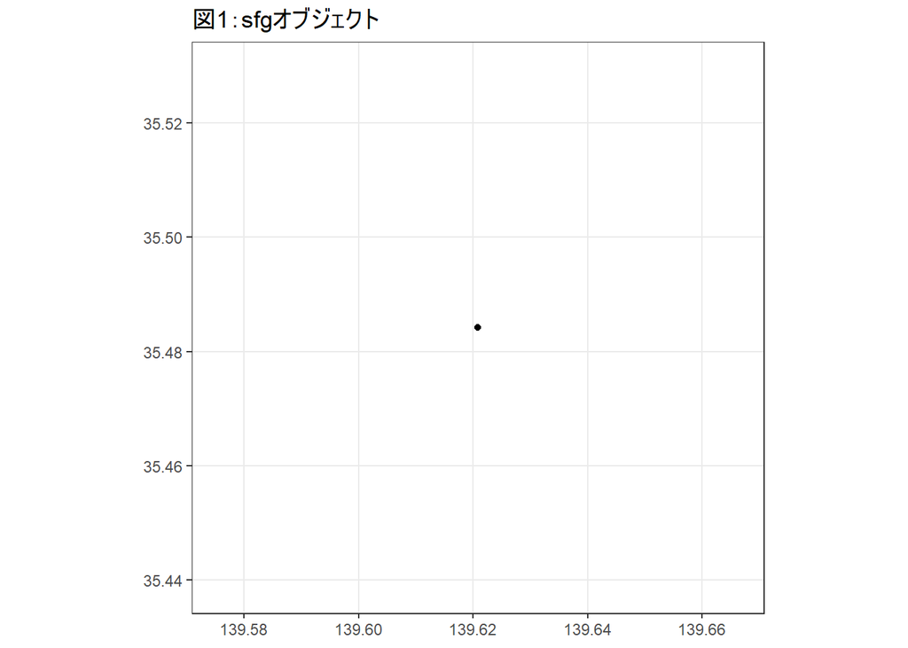

```r
ggplot()+
  geom_sf(data=KU_sfg)+
  ggtitle("図1：sfgオブジェクト")+
  theme_bw()
```

- しかし，座標参照系が与えられていないため，この点は東経`139.62`°あたり，北緯`35.48`°あたりを指しているわけではない．

## 3.2 `sfc`オブジェクト

- `sfc`オブジェクト：点，線，面を表す地理空間情報．`sfg`オブジェクトとの違いは，複数の地理空間情報を格納でき，かつ座標参照系（`CRS`）を含むことが可能．
  - 立地点として東急東横線白楽駅とセブン-イレブン横浜六角橋2丁目店も加え，この二点についても上と同じ手順で`sfg`オブジェクトにする．
  - `st_sfc()`を用いて，`stg`オブジェクトを`sfc`オブジェクトに変換．`crs=`で座標参照系を設定．
    - `st_sfc()`は新しく`sfc`オブジェクトを作成．それに対して，`st_as_sfc()`はすでにあるデータを`sfc`オブジェクトに変換．例えば，`st_bbox()`などの地理空間情報で作成された境界ボックス（数値のリスト）を`sfc`オブジェクトに変換する際に利用．

```r
#白楽駅，セブン-イレブンの位置（経度，緯度の順，世界測地系）
Hakuraku <- c(139.6278862, 35.4894679)

Seven_Eleven <- c(139.6235194, 35.4866059)

#sfgオブジェクトの作成
Hakuraku_sfg <- Hakuraku %>%
  st_point()

Seven_Eleven_sfg <- Seven_Eleven %>%
  st_point()

#sfcオブジェクトの作成
KU_sfc <- st_sfc(KU_sfg, Hakuraku_sfg,
                 Seven_Eleven_sfg, crs=4326)

#sfcオブジェクトの内容
KU_sfc %>% head()
```

```
## Geometry set for 3 features
## Geometry type: POINT
## Dimension:     XY
## Bounding box:  xmin: 139.6208 ymin: 35.48417 xmax: 139.6279 ymax: 35.48947
## Geodetic CRS:  WGS 84
```

```
## POINT (139.6208 35.48417)
```

```
## POINT (139.6279 35.48947)
```

```
## POINT (139.6235 35.48661)
```

- 座標参照系が設定されている．
- ポイントのみ格納されていることがわかる．

**`sfc`オブジェクトの可視化**

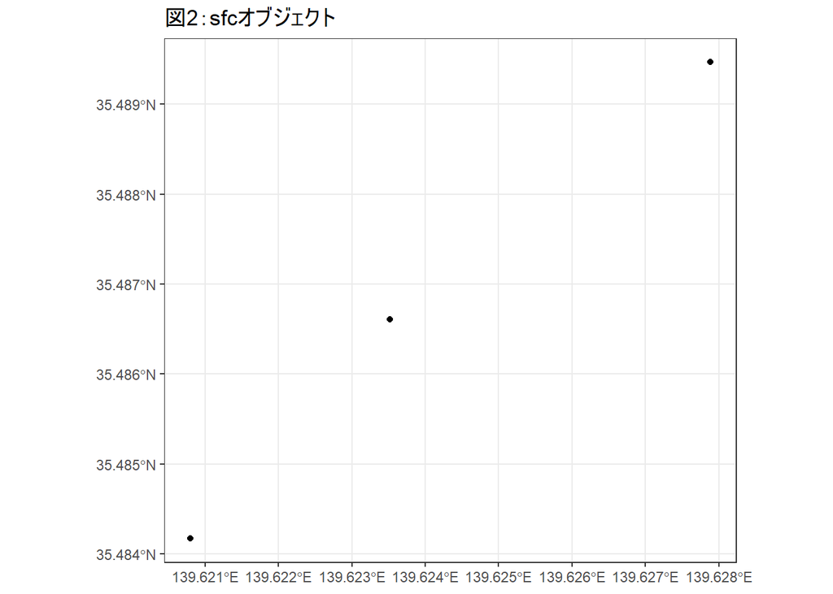

```r
ggplot()+
  geom_sf(data=KU_sfc)+
  ggtitle("図2：sfcオブジェクト")+
  theme_bw()
```

- 図1とは異なり，座標参照系が設定されているため，横軸が東経，縦軸が北緯を表していることが確認できる．
- 右上のポイントが「白楽駅」の位置を，左下のポイントが「神奈川大学」の位置を，その2点の中間のポイントが「セブン-イレブン」の位置だが，`sfc`オブジェクトは属性を含んでいないため，どのポイントが「神奈川大学」を指すかわからない．

## 3.3 `sf`オブジェクト

- `sf`オブジェクト：点，線，面を表す地理空間情報．最大の特徴は属性情報を含み，データフレームであること．
  - 先ほど作成した`sfc`オブジェクトに`sf`オブジェクトに変更し，属性として`地名`を加える．
  - `st_sf()`を用いて，`stc`オブジェクトを`sf`オブジェクトに変換．
  - `st_sc()`は新しく`sf`オブジェクトを作成．それに対して，`st_as_sfc()`はすでにあるデータを`sf`オブジェクトに変換．
- 地名を作成し，`sf`オブジェクト（`KU_sf`）に追加（`mutate()`）．

```r
#sfオブジェクトの作成
KU_sf <- st_sf(KU_sfc)

#地名作成
地名 <- c("神奈川大学", "白楽駅", "セブン-イレブン")

#地名の追加
KU_sf <- KU_sf %>%
  mutate(地名=地名)

#KU_sfの内容
KU_sf %>% head()
```

| KU_sfc | 地名 |
| --- | --- |
| POINT (139.6208 35.48417) | 神奈川大学 |
| POINT (139.6279 35.48947) | 白楽駅 |
| POINT (139.6235 35.48661) | セブン-イレブン |

- 地名が加わった`sf`オブジェクト（データフレーム）になっている．

**`sf`オブジェクトの可視化**

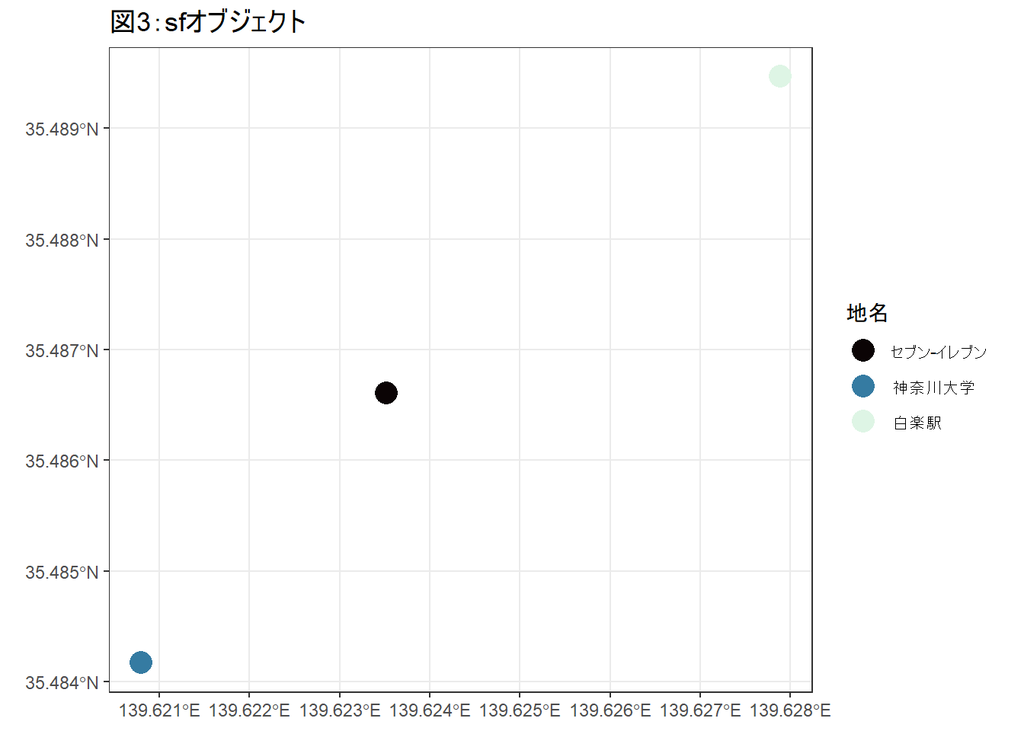

```r
ggplot()+
  geom_sf(data=KU_sf, aes(color=地名),
          size=5)+
  scale_color_viridis_d(option="G")+
  ggtitle("図3：sfオブジェクト")+
  theme_bw()
```

- 図3は`地名`を色分け，凡例により識別している．`地名`列によりこのようなことが可能に．

**Rによる地理空間データの可視化**

チュートリアル[ホーム](https://shinichiro-iwata.github.io/geospatial-data-visualization/)

**参考文献**

- 湯谷啓明（2018）「付録A sfパッケージ」Brunsdon, C. & Comber, L.著（湯谷啓明・工藤和奏・市川太祐訳）[『Rによる地理空間データ解析入門』](https://www.kyoritsu-pub.co.jp/book/b10003125.html)共立出版，pp.331-386．

**アイコン**

Font Awesome 6.7.2

**生成AIの使用について**

本稿の作成過程において，ChatGPTを使用してコードに関する助言を得た．サービスを利用した後，内容を確認し，必要に応じて編集を行った．